# Time Series Analysis

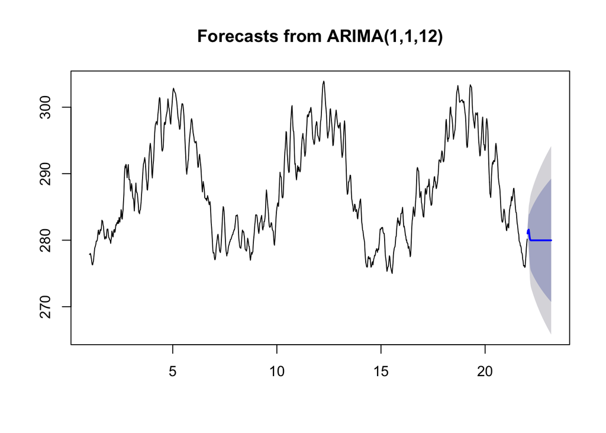

```r
fcast1 <- forecast(fit3, h=60)
plot(fcast1)
```

This fit gives us a clearer trend. Let’s fit it once more with observed data.

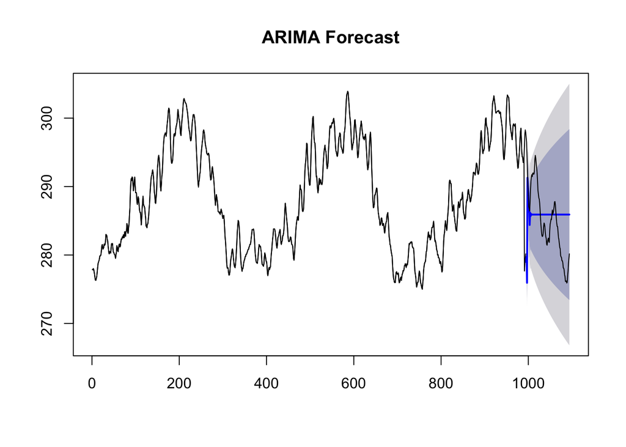

[figure not shown]

```r
hold <- window(ts(deseasonal_cnt), start = 991)
fit_no_holdout = arima(ts(deseasonal_cnt[-c(991:1090)]), order = c(1,1,12))
fcast_no_holdout <- forecast(fit_no_holdout,h=100)
plot(fcast_no_holdout, main='ARIMA Forecast')
lines(ts(deseasonal_cnt)) #a bit better, but not ideal
```

The model is getting better, but let’s find the ideal values. Let’s try the autofit provided by the forecast package, which optimizes the p,d,q values

```r
#get auto fit p,d,q values
auto.arima(deseasonal_cnt, seasonal = FALSE) #ideal ARIMA is (p=1,d=0,q=4)
```

```
## Series: deseasonal_cnt
## ARIMA(1,0,4) with non-zero mean
##
## Coefficients:
##          ar1     ma1     ma2     ma3     ma4      mean
##       0.9789  0.9287  0.2028  0.3216  0.5486  287.5877
## s.e.  0.0062  0.0351  0.0573  0.0322  0.0595    2.1928
##
## sigma^2 estimated as 0.2825:  log likelihood=-862.18
## AIC=1738.36   AICc=1738.46   BIC=1773.34
```

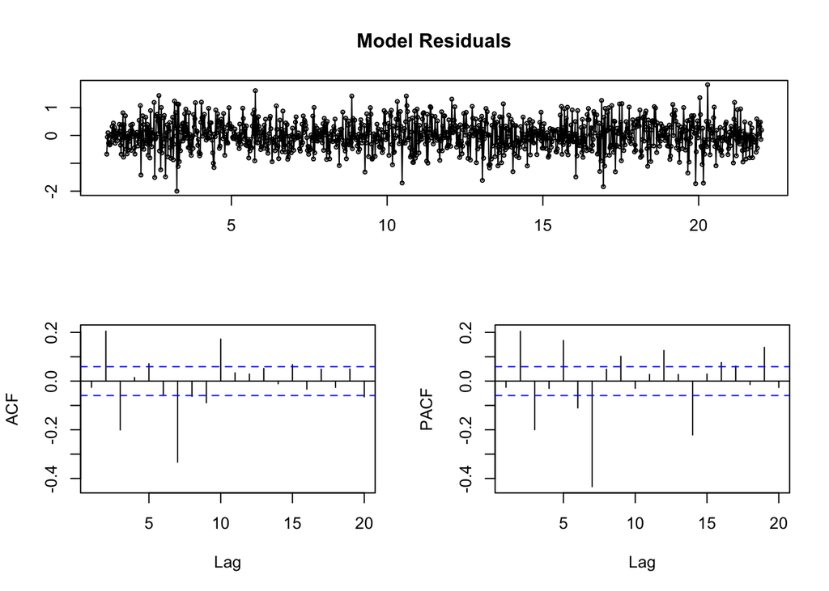

```r
fit4 = arima(deseasonal_cnt, order=c(1,0,4))
tsdisplay(residuals(fit4), lag.max = 20, main = "Model Residuals")
```

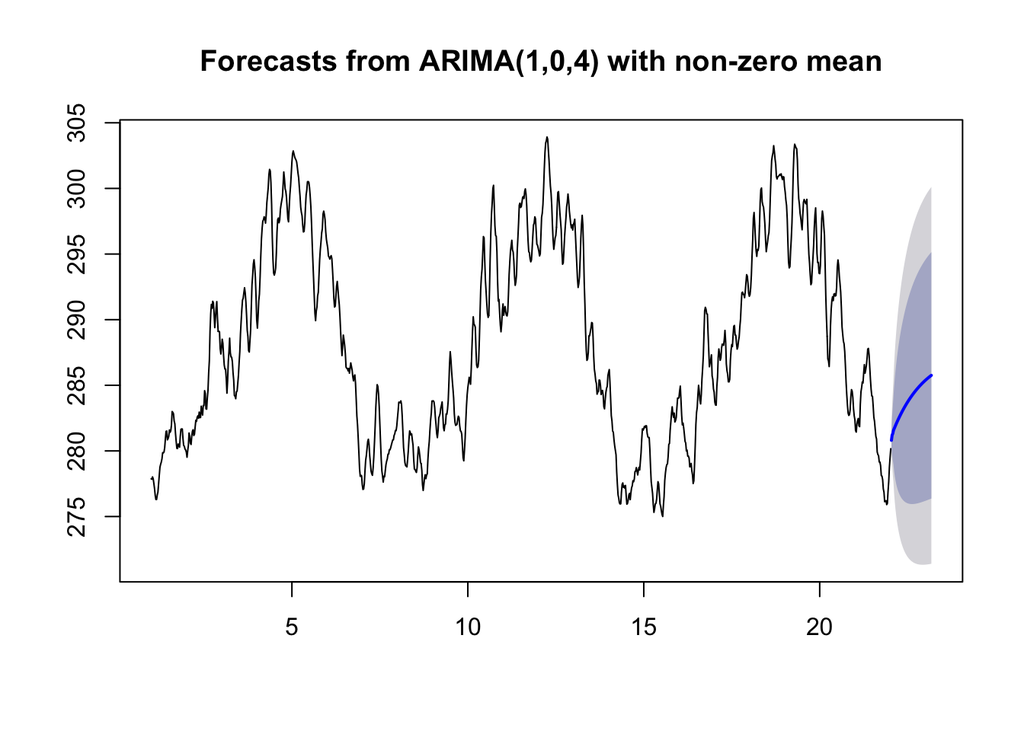

```r
fcast2 <- forecast(fit4, h=60)
plot(fcast2)
```

This model looks much better. let’s try fitting this with observed data.

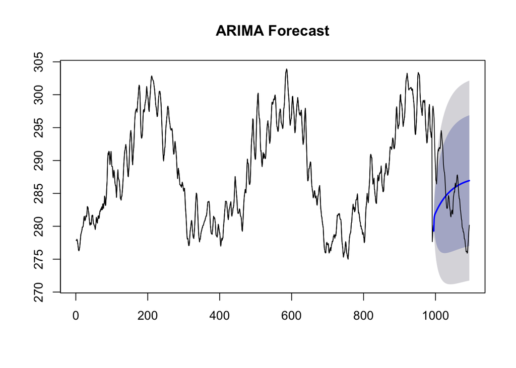

[figure not shown]

```r
hold <- window(ts(deseasonal_cnt), start = 991)
fit_no_holdout = arima(ts(deseasonal_cnt[-c(991:1090)]), order = c(1,0,4))
fcast_no_holdout <- forecast(fit_no_holdout,h=100)
plot(fcast_no_holdout, main='ARIMA Forecast')
lines(ts(deseasonal_cnt))
```

This looks much better than the previous attempts.

# Fourier Transform

## A Note

This code has been sourced and modified from João Neto’s “Fourier Transform: A R Tutorial” 2013, http://www.di.fc.ul.pt/~jpn/r/fourier/fourier.html.

The interactive provided by the link has been sourced thorugh “An Interactive Guide To The Fourier Transform” by “Better Explained.”

## The basics: Waves

### Simple Wave

Before we get into what the Fourier Transform is, lets review what a wave is, in particular a sine wave

Here we have a simple sine wave. It has a total of four basic components.  
1. **Amplitude**: how tall is the wave  
2. **Frequency**: how often does it repeat itself, 1/period  
3. **Phase**: at what part of the cycle does the wave start  
4. **Translations**: where is the waves’s center of mass

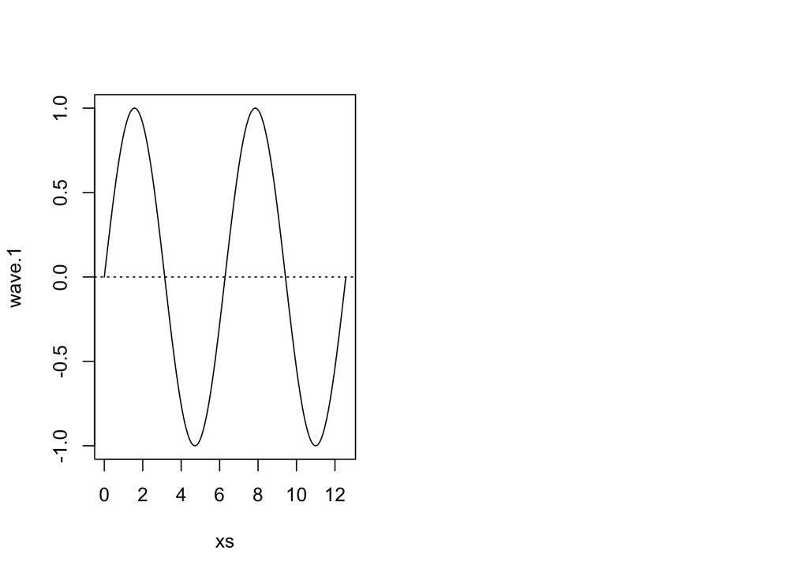

```r
xs <- seq(0,4*pi,pi/100)
wave.1 <- sin(xs)
par(mfrow = c(1, 2))
plot(xs,wave.1,type="l"); abline(h=0,lty=3)
```

Lets play around with different waves.

```r
#Simple function to plot a wave
wave.func <- function(amp = 1, freq = 4, phase = 0, trans = 0, length = 30) {
  xs <- seq(0,length,1/100)
  wave <-  trans + amp*sin(freq*xs+phase)
  plot(xs,wave,type="l")
  abline(h=0,lty=3)
  return(wave)
}
```

```r
x =  wave.func(amp = 3, freq = 4, phase = 1, trans = 1)
```

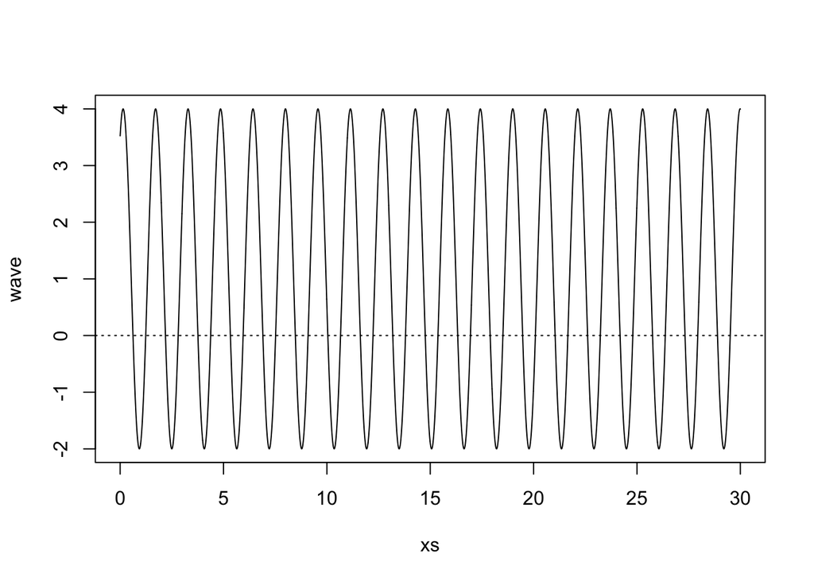

```r
y = wave.func(amp = 3, freq = .5, phase = 1, trans = 1)
```

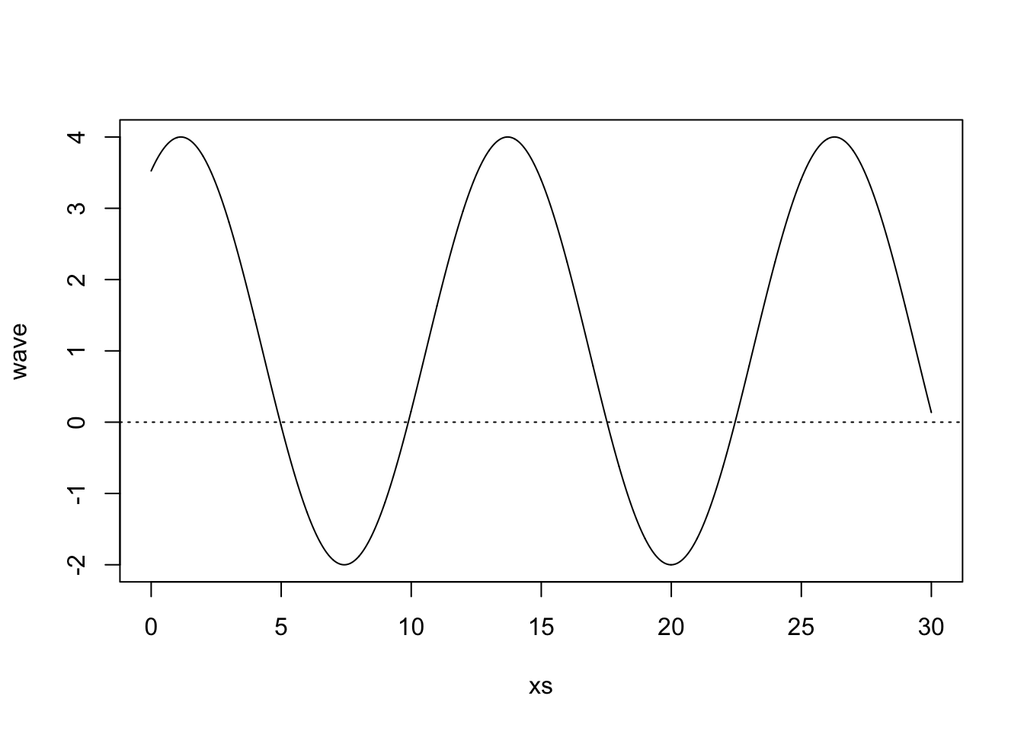

```r
z = wave.func(amp = 5, freq = 1, phase = 3, trans = 2)
```

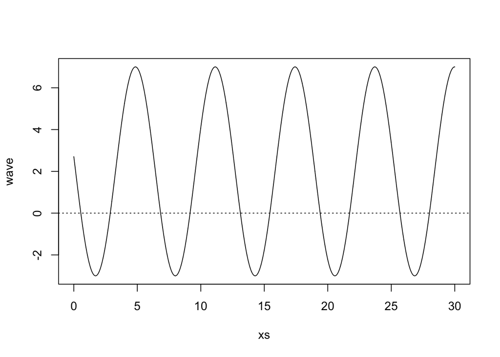

### Complex Wave

Now lets look at a complex wave. Lets linearly combine the three previous waves.

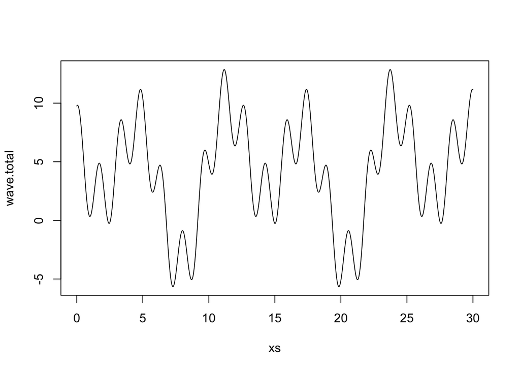

```r
xs <- seq(0,30,1/100)
wave.total = x+y+z
plot(xs,wave.total,type="l")
```

As we can see it repeats itself over time. The idea that we can combine simple waves into more complex ones is at the core of the **Forier Series**.  
It was **Joseph Fourier** who demonstrated that “any periodic wave can be represented by a sum of simple sine waves.”

$$f(t) = a_0 + \sum_{k} a_k * sin(kwt+p_k)$$
Where:
$a_0$ is the DC component
w = 2$\pi f_0$ where $f_0$ is the fundamental frequency of original wave
$a_k * sin(kwt+p_k)$ is called the harmonic, note the harmonic has to be less than the overall wave

This is all good but what about nonrepeating patterns?

## Fourier Transform

Instead of simple sine waves, the fourier transform (FT) breaks the complex wave down into circular motions.

The FT sends the trajectory(your timeseries) through a series of filters.  
* the FT pulls a “wave” compnent from your signal and leaves a remainder  
* it then iterates untill there is no remainder left  
* these filters are independent

Three principle components of the circular wave  
1. Strength: how strong is the signal  
2. Speed: how fast is it repeating, related to freuqency  
3. Delay: where does it start

Very similar to the descriptions of a simple wave

Here is a link to a great animation demonstrating this consept.  
https://betterexplained.com/examples/fourier/?cycles=1,2,3

The FT goes through your data and breaks them in to thier circular wave compoentns.

$$X_k = \sum_{n = 0}^{N-1}x_ne^{-i*2\pi*k*n/N}$$

#### A couple of notes.

Can’t have a frequency bigger than 1/(total time). Mind you I am glossing over underlying imaginary numbers behind this. For more details there is a great video: https://www.youtube.com/watch?v=spUNpyF58BY

### Example

Ok then lets look at an example of this in aciton and what it will look like.

This is a function to create a complex wave so we can generate some examples.

```r
plot.fourier <- function(fourier.series, f.0, ts) {
  w <- 2*pi*f.0
  trajectory <- sapply(ts, function(t) fourier.series(t,w))
  plot(ts, trajectory, type="l", xlab="time", ylab="f(t)"); abline(h=0,lty=3)
}
```

This is a function to visualize the results of a fft.

```r
plot.frequency.spectrum <- function(X.k, xlimits=c(0,length(X.k))) {
  plot.data  <- cbind(0:(length(X.k)-1), Mod(X.k))

  # TODO: why this scaling is necessary?
  plot.data[2:length(X.k),2] <- 2*plot.data[2:length(X.k),2]

  plot(plot.data, t="h", lwd=2, main="",
       xlab="Frequency (Hz)", ylab="Strength",
       xlim=xlimits, ylim=c(0,max(Mod(plot.data[,2]))))
}
```

Lets generate a wave to work with.

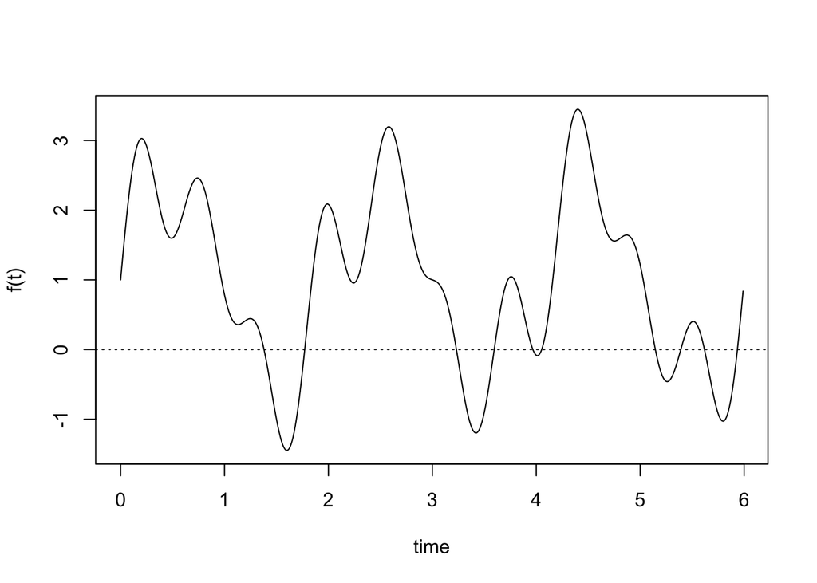

```r
acq.freq <- 100                    # data acquisition (sample) frequency (Hz)
time     <- 6                      # measuring time interval (seconds)
ts       <- seq(0,time-1/acq.freq,1/acq.freq) # vector of sampling time-points (s)
f.0 <- 1/time

dc.component <- 1
component.freqs <- c(3,7,10)        # frequency of signal components (Hz)
component.delay <- c(0,0,0)         # delay of signal components (radians)
component.strength <- c(1.5,.5,.75) # strength of signal components

f   <- function(t,w) {
  dc.component +
    sum( component.strength * sin(component.freqs*w*t + component.delay))
}

plot.fourier(f,f.0,ts=ts)
```

Of course we wouldn’t have the full funciton in the real world so lets resample the trajectory.

```r
w <- 2*pi*f.0
trajectory <- sapply(ts, function(t) f(t,w))
head(trajectory,n=30)
```

```
##  [1] 1.000000 1.162132 1.323161 1.481997 1.637568 1.788836 1.934801
##  [8] 2.074515 2.207089 2.331703 2.447610 2.554146 2.650736 2.736896
## [15] 2.812242 2.876489 2.929454 2.971057 3.001324 3.020382 3.028458
## [22] 3.025877 3.013056 2.990502 2.958803 2.918623 2.870694 2.815807
## [29] 2.754805 2.688575
```

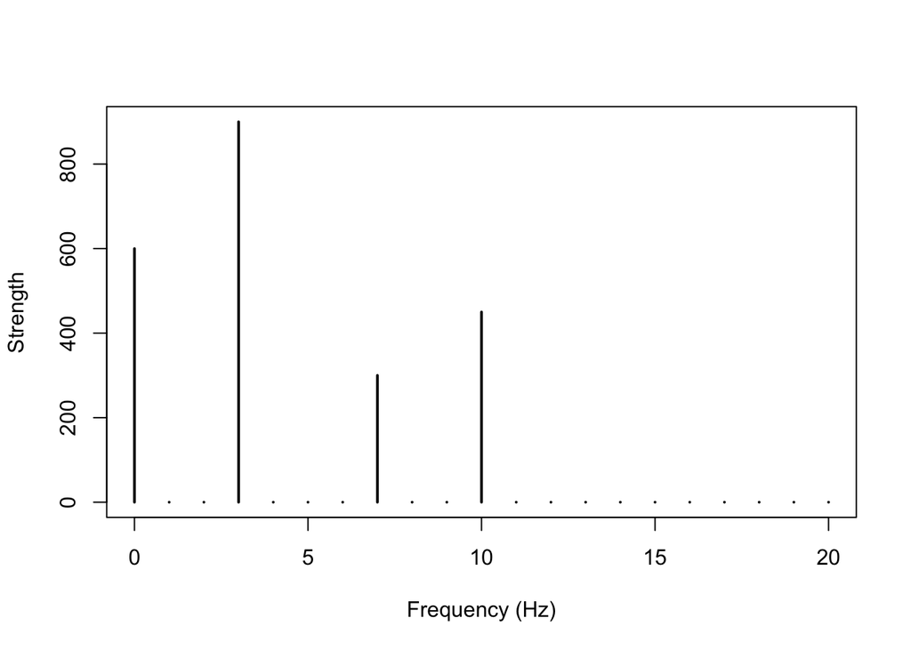

```r
X.k <- fft(trajectory)                   # find all harmonics with fft()
plot.frequency.spectrum(X.k, xlimits=c(0,20))
```

Here we have the major frequencies and their relative strength.